# IRT Parameters for CAT

George Kachergis & Michael C. Frank

2021-11-19

# Overview

The “mod_2pl” files (for Spanish/English, production/comprehension) each contain a coefs_2pl dataframe of the item parameters (in mirt’s slope-intercept form), as well as a mod_2pl mirt model object, and fscores_2pl (the estimated ability parameters from Wordbank participants).

# Production

## English

```r
it = list() # item parameters
ab = list() # child ability
load("production/eng_ws_wg_mod_2pl_nobad.Rds")
it$en_prod <- coefs_2pl # 680 WS items
ab$en_prod <- fscores_2pl

load("production/preferredCAT_eng.Rds")
```

Productive CDI vocabulary of 7633 English-speaking children ages 12-36 months used to fit a 2PL model with 679 items (after pruning).

## Spanish

```r
load("production/sp_ws_wg_mod_2pl_nobad.Rds")
it$sp_prod <- coefs_2pl
ab$sp_prod <- fscores_2pl

load("production/preferredCAT_sp.Rds")
```

Productive CDI vocabulary of 1610 Spanish-speaking children ages 12-30 months used to fit a 2PL model with 679 items (after pruning).

# Comprehension

## English

```r
load("comprehension/eng_wg_mod_2pl.Rds")
it$en_comp <- coefs_2pl
ab$en_comp <- fscores_2pl
```

Receptive CDI:WG vocabulary of 2394 English-speaking children used to fit a 2PL model with 396 items (after pruning).

## Spanish

```r
load("comprehension/sp_wg_mod_2pl.Rds")
it$sp_comp <- coefs_2pl
ab$sp_comp <- fscores_2pl
```

Receptive CDI:WG vocabulary of 759 Spanish-speaking children used to fit a 2PL model with 428 items (after pruning).

# Comprehension vs. Production Item Parameters

How correlated are parameters for comprehension and production?

## Item Difficulty

```r
en_comp_prod_match <- intersect(it$en_prod$definition, it$en_comp$definition) # 394
setdiff(it$en_comp$definition, it$en_prod$definition) # in and inside
```

```
## [1] "daddy*" "in"     "inside"
```

```r
sp_comp_prod_match <- intersect(it$sp_comp$definition, it$sp_prod$definition) # 389
setdiff(it$sp_comp$definition, it$sp_prod$definition)
```

```
##  [1] "¡salud!"                "acabar(se)"             "alla/allí"
##  [4] "bolsa"                  "brazos"                 "buenas día"
##  [7] "cabra"                  "calcetines"             "camión de bomberos"
## [10] "contento"               "cuidado"                "dedos"
## [13] "dónde está"             "el (articles)"          "escalera"
## [16] "hacer la meme"          "llaves"                 "mamá/mami"
## [19] "manos (body_parts)"     "manos (games_routines)" "miedo"
## [22] "mojar(se)"              "no"                     "orejas"
## [25] "papá/papi"              "pipí (coche)"           "poco"
## [28] "qué"                    "secar(se)"              "sed"
## [31] "shh"                    "subir"                  "sueño"
## [34] "también"                "te"                     "temprano"
## [37] "trabajar"               "uno dos tres"           "vaso"
## [40] "ver"
```

```r
# 39 items - can match some of these (e.g., escalera/s, brazo/s, oreja/s...)

all <- it$en_prod %>%
  mutate(Language = "EN", Task = "Production") %>%
  bind_rows(it$en_comp %>% mutate(Language = "EN", Task = "Comprehension")) %>%
  bind_rows(it$sp_comp %>% mutate(Language = "SP", Task = "Comprehension")) %>%
  bind_rows(it$sp_prod %>% mutate(Language = "SP", Task = "Production"))


all_wide <- all %>% group_by(Language) %>% select(-g, -u) %>%
  pivot_wider(names_from = Task, values_from=c(a1, d))

m_d <- lm(d_Comprehension ~ d_Production*Language, data = all_wide)
m_a1 <- lm(a1_Comprehension ~ a1_Production*Language, data = all_wide)

all_wide <- all_wide %>% add_residuals(m_d) %>%
    rename(d_resid = resid) %>%
    add_residuals(m_a1) %>%
    rename(a1_resid = resid)

#corrr::correlate(all_wide %>% select(d_Comprehension, d_Production))
```

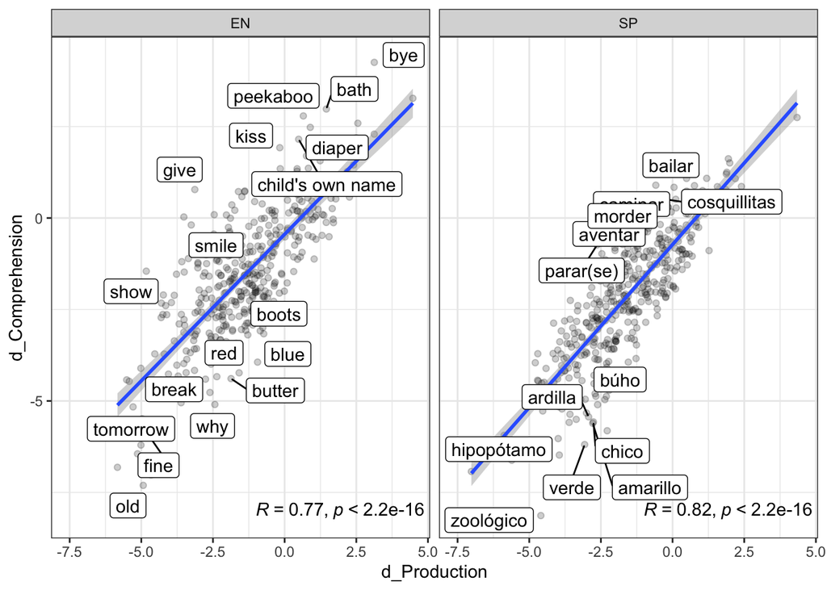

Strong correlation between comprehension and production item difficulties. Outliers with easier comprehension than production seem to be mostly verbs.

## Item Discrimination

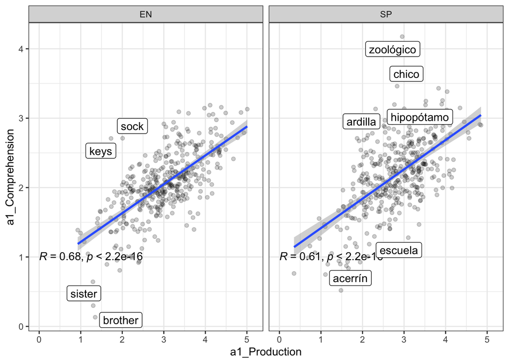

# Compare Children’s Comprehension vs. Production Ability Estimates

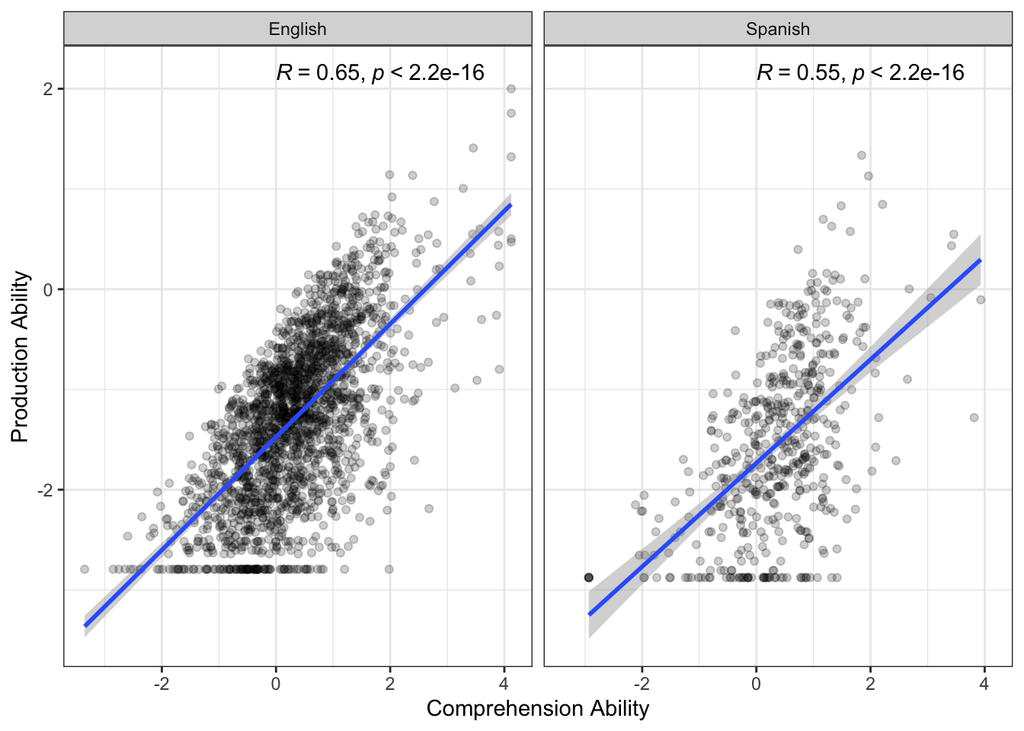

Strong correlations between children’s estimated comprehension and production abilities (same or stronger correlation as comprehension vs. production sumscores?).

# Predicting Total Vocabulary Size from Ability

Fit GLM to predict vocabulary size from IRT ability (and age and sex?).

```r
en_comp <- lm(comprehension ~ age + sex + ability,
                       data=demo$en_comp)
summary(en_comp)
```

```
##
## Call:
## lm(formula = comprehension ~ age + sex + ability, data = demo$en_comp)
##
## Residuals:
##     Min      1Q  Median      3Q     Max
## -89.948 -20.459  -7.788  17.232 157.691
##
## Coefficients:
##             Estimate Std. Error t value Pr(>|t|)
## (Intercept) 127.7731     4.1488  30.798   <2e-16 ***
## age           0.3017     0.3008   1.003    0.316
## sexMale      -0.8908     1.0995  -0.810    0.418
## ability      85.6924     0.6674 128.401   <2e-16 ***
## ---
## Signif. codes:  0 '***' 0.001 '**' 0.01 '*' 0.05 '.' 0.1 ' ' 1
##
## Residual standard error: 26.72 on 2388 degrees of freedom
##   (2 observations deleted due to missingness)
## Multiple R-squared:  0.9204, Adjusted R-squared:  0.9203
## F-statistic:  9202 on 3 and 2388 DF,  p-value: < 2.2e-16
```

```r
en_prod <- lm(production ~ age + sex + ability,
                       data=demo$en_prod)
summary(en_prod)
```

```
##
## Call:
## lm(formula = production ~ age + sex + ability, data = demo$en_prod)
##
## Residuals:
##      Min       1Q   Median       3Q      Max
## -180.759  -47.870   -1.077   45.629  297.779
##
## Coefficients:
##             Estimate Std. Error t value Pr(>|t|)
## (Intercept) 109.1249     6.2784  17.381   <2e-16 ***
## age           4.9944     0.2908  17.176   <2e-16 ***
## sexMale      -4.7793     1.9039  -2.510   0.0121 *
## sexOther      5.3828    43.0742   0.125   0.9006
## ability     171.3591     1.3063 131.177   <2e-16 ***
## ---
## Signif. codes:  0 '***' 0.001 '**' 0.01 '*' 0.05 '.' 0.1 ' ' 1
##
## Residual standard error: 60.79 on 4157 degrees of freedom
##   (3835 observations deleted due to missingness)
## Multiple R-squared:  0.9244, Adjusted R-squared:  0.9243
## F-statistic: 1.271e+04 on 4 and 4157 DF,  p-value: < 2.2e-16
```

```r
# cor(demo$en_comp$comprehension, demo$en_comp$ability) # .96
# cor(demo$en_comp$age, demo$en_comp$ability) # .62
```

# Preferred CAT Settings

The above item parameters can be used to run a CAT, for example with the mirtCAT package. Based on real data simulations, we recommend a minimum of 25 items, a maximum of 50, with termination at SE = .15, and ML scoring. In the below call, the maximally-informative (MI) start item is chosen, but we can instead supply an age-based starting item (based on mean theta for each age) if you can use that.

```r
mirtCAT(mo = mod_2pl, criteria = 'MI', start_item = 'MI',
                     method = 'ML', cl = cl, #local_pattern = dat,
                     design = list(min_items = 25,
                                   max_items = 50,
                                   min_SEM = 0.15))
```